# Assignment6

Yuanyuan Pan

November 6, 2016

## 1. Separate mixed samples of linear model data using logistic regression

In addition to the main sample `ResidualAnalysisProjectData_1.csv` you are given the training sample `ResidualAnalysisProjectData_1_Train.csv` which indicates by which of the two mixed models each observation is generated (see column 3). Use this information to separate models in the main sample.

### 1.1. Analize the training sample

Read the training data.

```r
datapath = getwd()
LinearModel.Training<-read.csv(file=paste(datapath,'ResidualAnalysisProjectData_1_Train.csv',sep="/"),
                               header=TRUE,sep=",")
nSample.Training<-length(LinearModel.Training[,1])
head(LinearModel.Training)
```

```
##        Input     Output Model.Switch
## 1  3.6664327  3.4295281            1
## 2 -2.5194424 -2.5528623            0
## 3  0.6475581  1.5908455            1
## 4  2.4439621  1.8855023            1
## 5  1.9921334  0.1343168            0
## 6  1.7534556  2.8432003            1
```

Plot the training sample

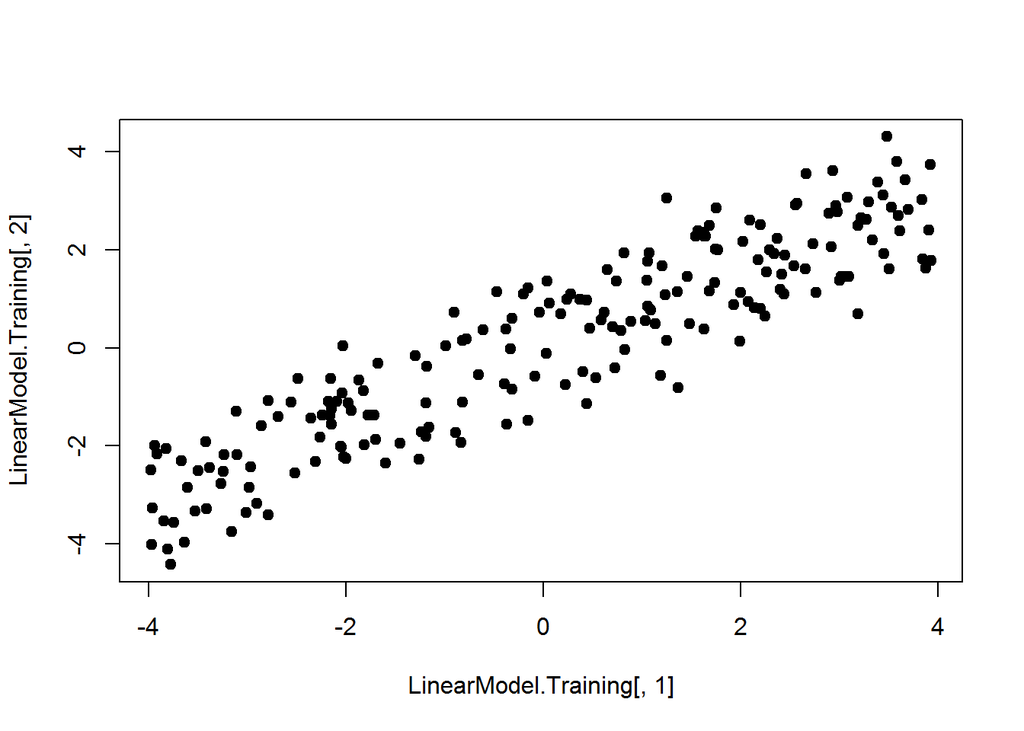

```r
plot(LinearModel.Training[,1],LinearModel.Training[,2], type="p",pch=19)
```

Then separate the models in the training sample using the third column and plot the training subsamples:

```r
# Define training samples generated by model 1 and model 2
LinearModel.Training.1<-cbind(LinearModel.Training[,1],rep(NA,nSample.Training))
LinearModel.Training.2<-cbind(LinearModel.Training[,1],rep(NA,nSample.Training))
LinearModel.Training.1[LinearModel.Training[,3]*(1:nSample.Training),2]<-
  LinearModel.Training[LinearModel.Training[,3]*(1:nSample.Training),2]
LinearModel.Training.2[(1-LinearModel.Training[,3])*(1:nSample.Training),2]<-
  LinearModel.Training[(1-LinearModel.Training[,3])*(1:nSample.Training),2]

head(cbind(LinearModel.Training,
           Trainig1=LinearModel.Training.1[,2],
           Training2=LinearModel.Training.2[,2]))
```

```
##        Input     Output Model.Switch Trainig1  Training2
## 1  3.6664327  3.4295281            1 3.429528         NA
## 2 -2.5194424 -2.5528623            0       NA -2.5528623
## 3  0.6475581  1.5908455            1 1.590846         NA
## 4  2.4439621  1.8855023            1 1.885502         NA
## 5  1.9921334  0.1343168            0       NA  0.1343168
## 6  1.7534556  2.8432003            1 2.843200         NA
```

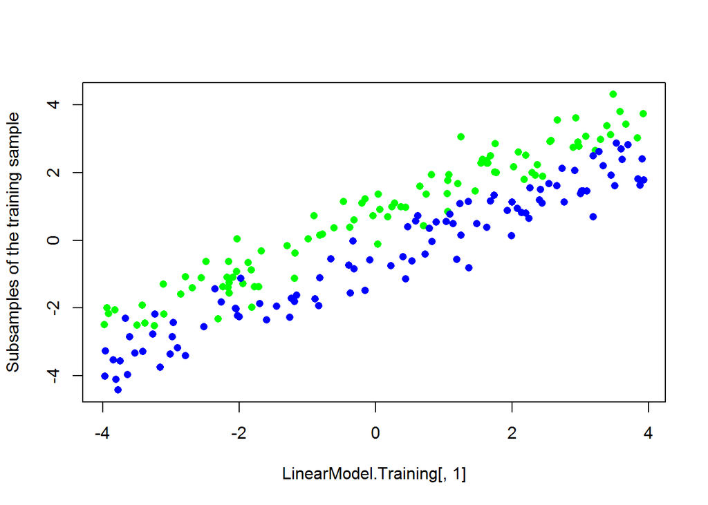

```r
# Plot the subsamples
matplot(LinearModel.Training[,1],cbind(LinearModel.Training.1[,2],LinearModel.Training.2[,2]),
        pch=16,col=c("green","blue"),ylab="Subsamples of the training sample")
```

Like in the project on analysis of residuals with `ResidualAnalysisProjectData_1.csv` estimate linear model for the training sample using function `lm`, look at the output of the function

```r
EstimatedLinearModel.Training <- lm(Output ~ Input, data = LinearModel.Training)
summary(EstimatedLinearModel.Training)$coefficients
```

```
##               Estimate Std. Error    t value     Pr(>|t|)
## (Intercept) 0.03864599 0.05860770  0.6594012 5.104044e-01
## Input       0.77157337 0.02490368 30.9823033 7.238330e-78
```

```r
summary(EstimatedLinearModel.Training)$r.squared
```

```
## [1] 0.8290012
```

```r
summary(EstimatedLinearModel.Training)$sigma
```

```
## [1] 0.8267488
```

Interpret the results in the output. Compare the results for the trainig sample and the main sample from previous week: coefficients, $R^2$, $\sigma$.Observe the residuals of the training sample.

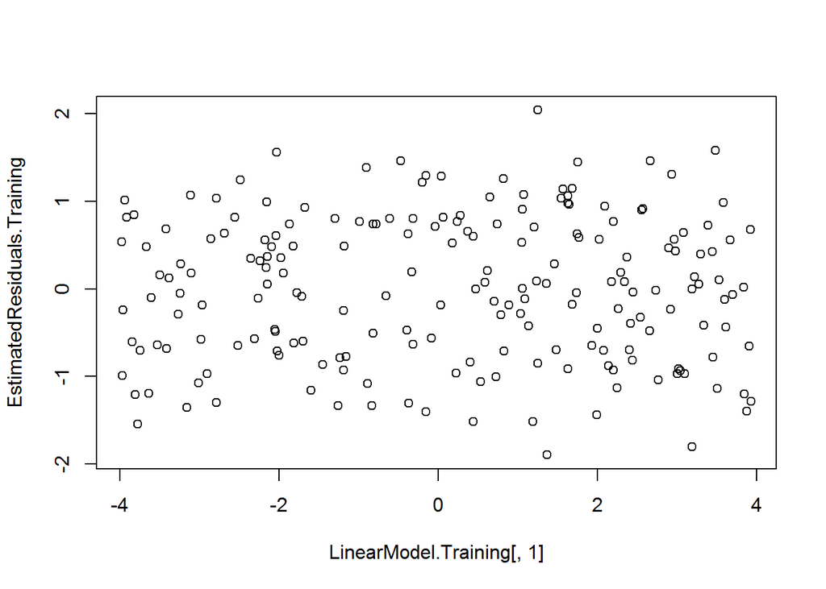

```r
EstimatedResiduals.Training<-EstimatedLinearModel.Training$residuals
plot(LinearModel.Training[,1],EstimatedResiduals.Training)
```

Using the third column of the training sample separate and plot the residuals for observations from different models

```r
# Define residuals corresponding to different models
EstimatedResiduals.Training.1<-EstimatedResiduals.Training
EstimatedResiduals.Training.2<-EstimatedResiduals.Training
EstimatedResiduals.Training.1[(LinearModel.Training[,3]==0)*(1:nSample.Training)]<-NA
EstimatedResiduals.Training.2[(LinearModel.Training[,3]==1)*(1:nSample.Training)]<-NA
# Print the first ten columns to check the separation
head(cbind(AllResiduals=EstimatedResiduals.Training,
      Training1Residuals=EstimatedResiduals.Training.1,
      Training2Residuals=EstimatedResiduals.Training.2,
      TrainingClass=LinearModel.Training[,3]))
```

```
##   AllResiduals Training1Residuals Training2Residuals TrainingClass
## 1   0.56196024         0.56196024                 NA             1
## 2  -0.64757362                 NA         -0.6475736             0
## 3   1.05256097         1.05256097                 NA             1
## 4  -0.03883971        -0.03883971                 NA             1
## 5  -1.44140627                 NA         -1.4414063             0
## 6   1.45163470         1.45163470                 NA             1
```

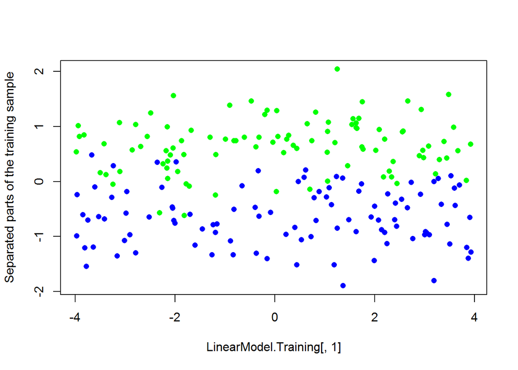

```r
# Plot the residuals corresponding to different models
matplot(LinearModel.Training[,1],cbind(EstimatedResiduals.Training.1,
                                       EstimatedResiduals.Training.2),
        pch=16,col=c("green","blue"),ylab="Separated parts of the training sample")
```

*What do you think about best way to separate the samples of residuals?*

### 1.2. Ligistic regression

Separate clusters of residuals using logistic regression with binary output from the third column and residuals of training sample as input.

Estimate logistic regression by calling `glm()` function.

Note: when we estimate logistic model we first create the data frame `Logistic.Model.Data` and use it in the call of `glm` as `glm(Logistic.Output~Logistic.Input,data=Logistic.Model.Data...` where Logistic.Input and Logistic.Output are the names of the data frame variables. This becomes important when we use the function predict later.

```r
# Create the data frame for logistic regression
Logistic.Model.Data<-data.frame(Logistic.Output=LinearModel.Training[,3],
                                Logistic.Input=EstimatedResiduals.Training)
LinearModel.Training.Logistic<-glm(Logistic.Output~Logistic.Input,data=Logistic.Model.Data,
                                   family=binomial(link=logit))
summary(LinearModel.Training.Logistic)
```

```
##
## Call:
## glm(formula = Logistic.Output ~ Logistic.Input, family = binomial(link = logit),
##     data = Logistic.Model.Data)
##
## Deviance Residuals:
##      Min        1Q    Median        3Q       Max
## -2.19898  -0.21506  -0.01018   0.24713   2.63249
##
## Coefficients:
##                Estimate Std. Error z value Pr(>|z|)
## (Intercept)     -0.2044     0.2680  -0.762    0.446
## Logistic.Input   5.2318     0.7928   6.599 4.14e-11 ***
## ---
## Signif. codes:  0 '***' 0.001 '**' 0.01 '*' 0.05 '.' 0.1 ' ' 1
##
## (Dispersion parameter for binomial family taken to be 1)
##
##     Null deviance: 277.239  on 199  degrees of freedom
## Residual deviance:  92.557  on 198  degrees of freedom
## AIC: 96.557
##
## Number of Fisher Scoring iterations: 7
```

```r
names(LinearModel.Training.Logistic)
```

```
##  [1] "coefficients"      "residuals"         "fitted.values"
##  [4] "effects"           "R"                 "rank"
##  [7] "qr"                "family"            "linear.predictors"
## [10] "deviance"          "aic"               "null.deviance"
## [13] "iter"              "weights"           "prior.weights"
## [16] "df.residual"       "df.null"           "y"
## [19] "converged"         "boundary"          "model"
## [22] "call"              "formula"           "terms"
## [25] "data"              "offset"            "control"
## [28] "method"            "contrasts"         "xlevels"
```

*Interpret the summary of the model: what is the meaning and significance of coefficients.*

Define and plot probability of selecting an observation from the first model using predict function with type=“response” argument. Plot the predicted probabilities

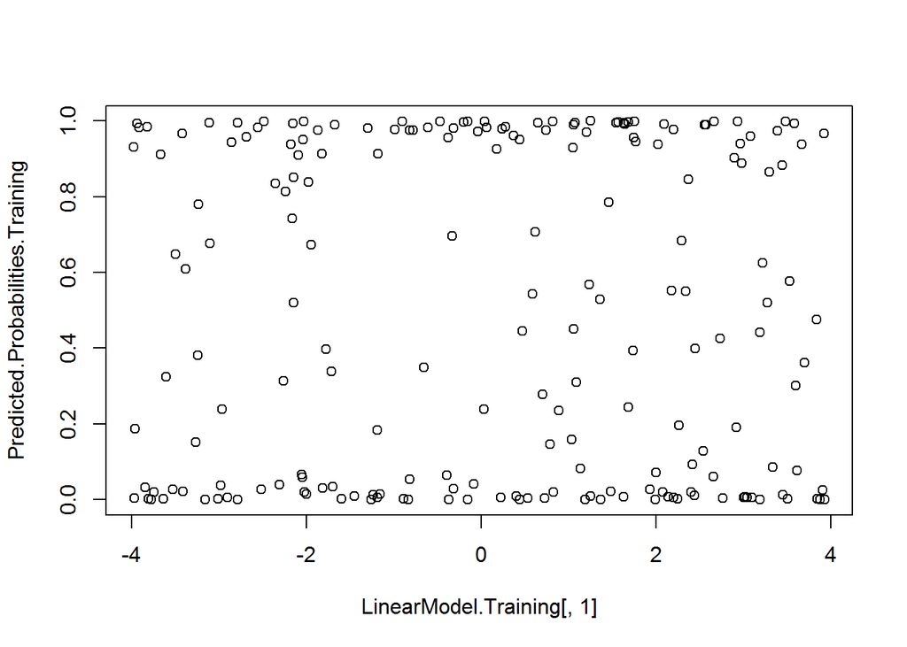

```r
Predicted.Probabilities.Training<-predict(LinearModel.Training.Logistic,type="response")
plot(LinearModel.Training[,1],Predicted.Probabilities.Training)
```

*How can we use this graph? What does it tell us?*

Classify the training sample using the estimated unscrambling sequence

```r
# Create the unscrambling sequence for the training sample
Unscrambling.Sequence.Training.Logistic<-
  (predict(LinearModel.Training.Logistic,type="response")>.5)*1
# Create classified residuals
ClassifiedResiduals.Training.1<-EstimatedResiduals.Training
ClassifiedResiduals.Training.2<-EstimatedResiduals.Training
ClassifiedResiduals.Training.1[(Unscrambling.Sequence.Training.Logistic==0)*
                                 (1:nSample.Training)]<-NA
ClassifiedResiduals.Training.2[(Unscrambling.Sequence.Training.Logistic==1)*
                                 (1:nSample.Training)]<-NA
head(cbind(AllTraining=EstimatedResiduals.Training,
           Training1=ClassifiedResiduals.Training.1,
           Training2=ClassifiedResiduals.Training.2))
```

```
##   AllTraining Training1   Training2
## 1  0.56196024 0.5619602          NA
## 2 -0.64757362        NA -0.64757362
## 3  1.05256097 1.0525610          NA
## 4 -0.03883971        NA -0.03883971
## 5 -1.44140627        NA -1.44140627
## 6  1.45163470 1.4516347          NA
```

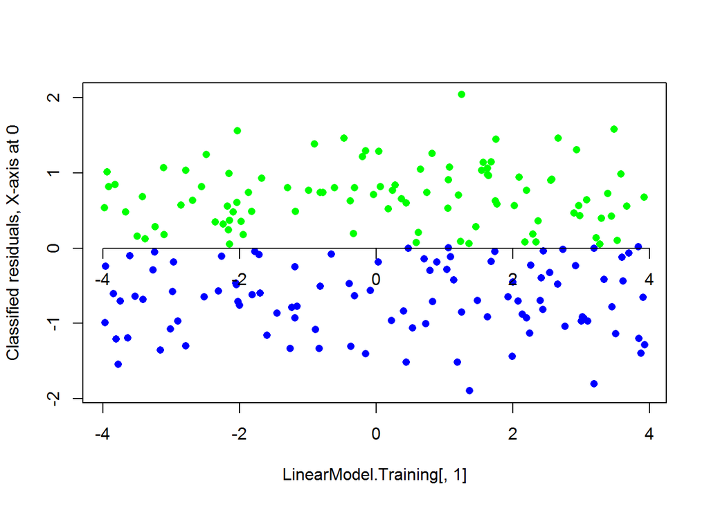

```r
# Plot both classes of the residuals
matplot(LinearModel.Training[,1],cbind(ClassifiedResiduals.Training.1,
                                       ClassifiedResiduals.Training.2),
        pch=16,col=c("green","blue"),ylab="Classified residuals, X-axis at 0")
axis(1,pos=0)
```

*Recall what classification rule we used in the previous assignment with these data?* *What is the classification rule estimated by logistic regression?*

Recall what variable is the predictor of the model.

*Calculate classification boundary for the models using estimated coefficients of logistic regression.*

```r
Classification.Rule.Logistic <- 0.2044/5.2318
Classification.Rule.Logistic
```

```
## [1] 0.03906877
```

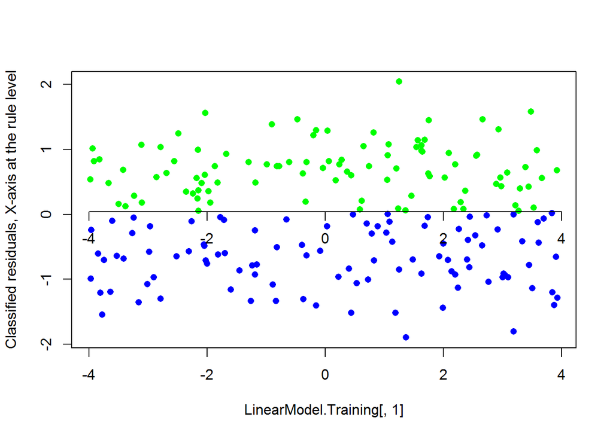

```r
matplot(LinearModel.Training[,1],cbind(ClassifiedResiduals.Training.1,
                                       ClassifiedResiduals.Training.2),
        pch=16,col=c("green","blue"),ylab="Classified residuals, X-axis at the rule level")
axis(1,pos=Classification.Rule.Logistic)
```